# Untitled

Para a realização dessa atividade eu utilizei os dados sobre os gastos dos parlamentares disponíveis no site de transparência do congresso nacional do ano de 2015. Utilizando apenas os gastos em **COMBUSTÍVEIS E LUBRIFICANTES** dos nossos parlamantares obtemos as seguintes informações:

```r
library(dplyr)
library(ggplot2)

# Dados da câmara dos deputados
file <- read.csv("AnoAtual.csv")

# Selecionando apenas os gastos de combustíveis e lubrificantes
vlrCombustiveis <- file %>%
  filter(txtDescricao == "COMBUSTÍVEIS E LUBRIFICANTES.") %>%
  select(vlrLiquido, numSubCota)

# Sumarry dos valores de combustíveis e lubrificantes
summary(vlrCombustiveis$vlrLiquido)
```

```
##    Min. 1st Qu.  Median    Mean 3rd Qu.    Max.
##    0.81   85.80  120.00  247.40  166.20 4500.00
```

Considerando os dados fornecidos como sendo a população temos que a media desse gasto é 247.40. Para se ter uma visão mais geral da distribuição desse gasto observe o gráfico abaixo.

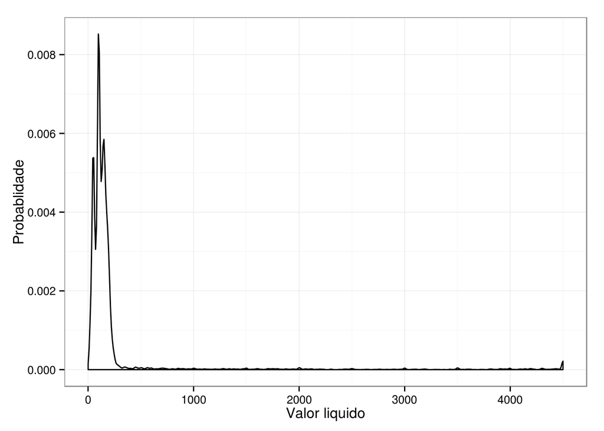

```r
# função de distribuição de probabilidade da variavel combustíveis e lubrificantes
ggplot(vlrCombustiveis, aes(vlrLiquido)) +
  geom_density() +
  labs(x='Valor liquido', y='Probablidade') +
  theme_bw()
```

Para uma melhor visualização do observe o mesmo gráfico agora com um “zoom”

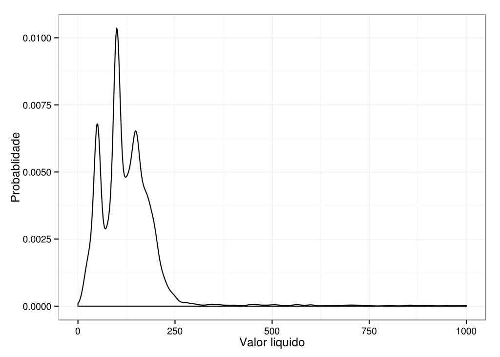

```r
# função de distribuição de probabilidade da variavel combustíveis e lubrificantes
ggplot(vlrCombustiveis, aes(vlrLiquido)) +
  xlim(0, 1000) +
  geom_density() +
  labs(x='Valor liquido', y='Probablidade') +
  theme_bw()
```

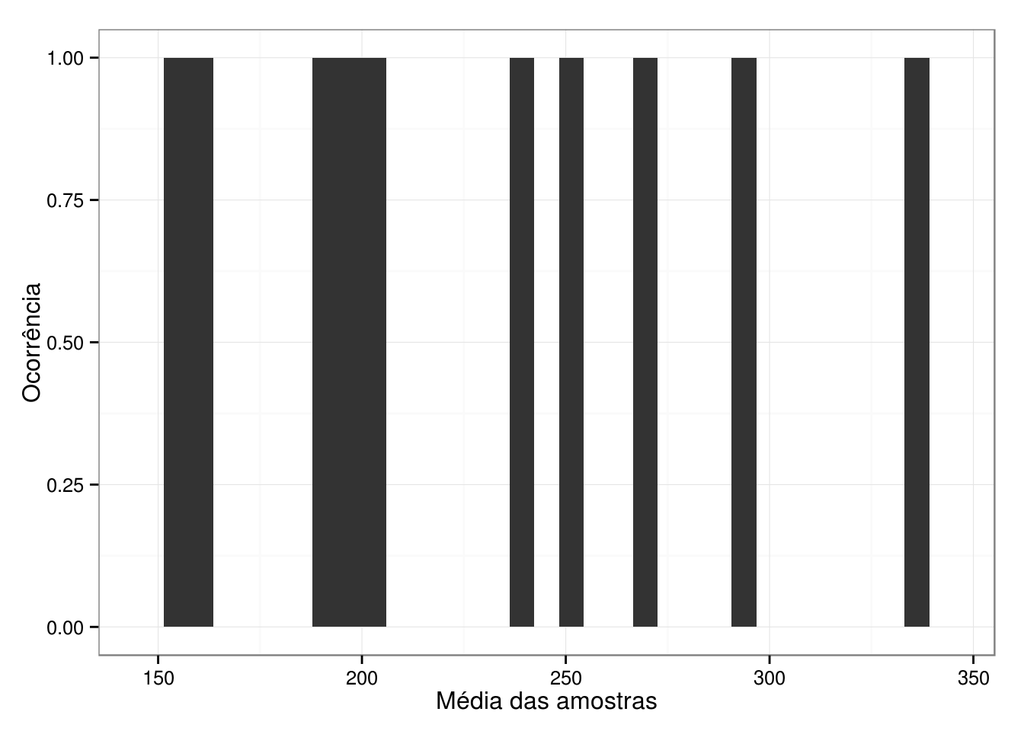

```r
mediaAmostra <- function(original, samplesSize, numSamples) {
  dist_original <- original
  sample_size <- samplesSize
  num_samples <- numSamples

  samples_means <- c()
  for(i in seq(1, num_samples)){
    a_sample <- sample(dist_original, sample_size)
    samples_means[i] <- mean(a_sample)
    }
  samples_means
  }

samplesMeans <- mediaAmostra(vlrCombustiveis$vlrLiquido, 100, 10)

ggplot(data.frame(samplesMeans), aes(samplesMeans)) +
  geom_histogram() +
  theme_bw() +
  labs(x='Média das amostras', y='Ocorrência')
```

É possível notas que a maioria dos valores não ficaram tão próximos da média da população. Por esse motivo irei repetir o experimento e dessa vez aumentar o número de amostras mantendo o número de observações de dentro das amostras contante (tamanho 100).

Para a média de 20 amostras temos:

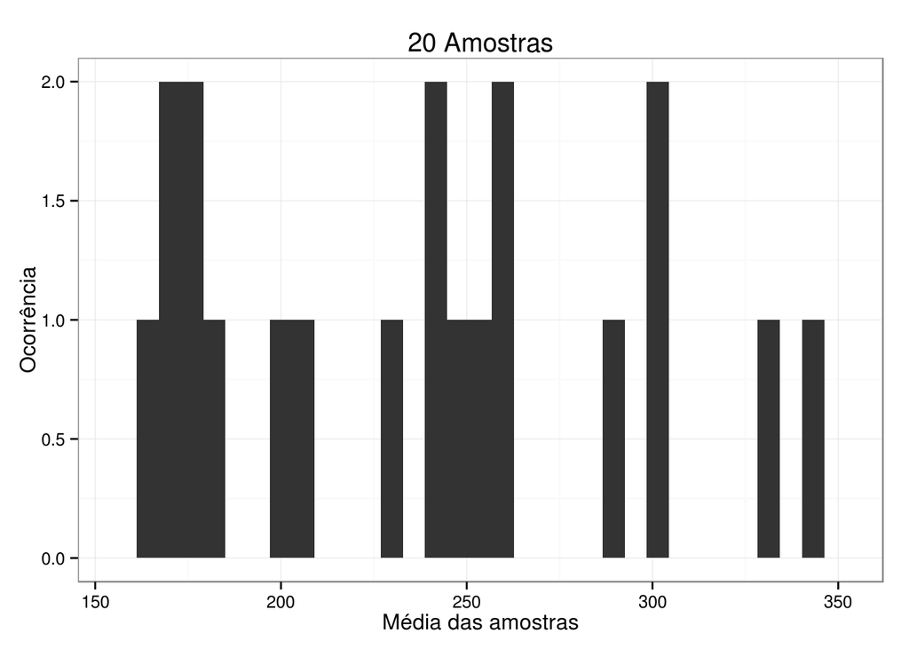

```r
# Média de 20 amostras com n = 100
samplesMeans <- mediaAmostra(vlrCombustiveis$vlrLiquido, 100, 20)
g1 <- ggplot(data.frame(samplesMeans), aes(samplesMeans)) + geom_histogram() +  theme_bw() +
  labs(x='Média das amostras', y='Ocorrência') + ggtitle("20 Amostras")
g1
```

Para a média de 40 amostras temos:

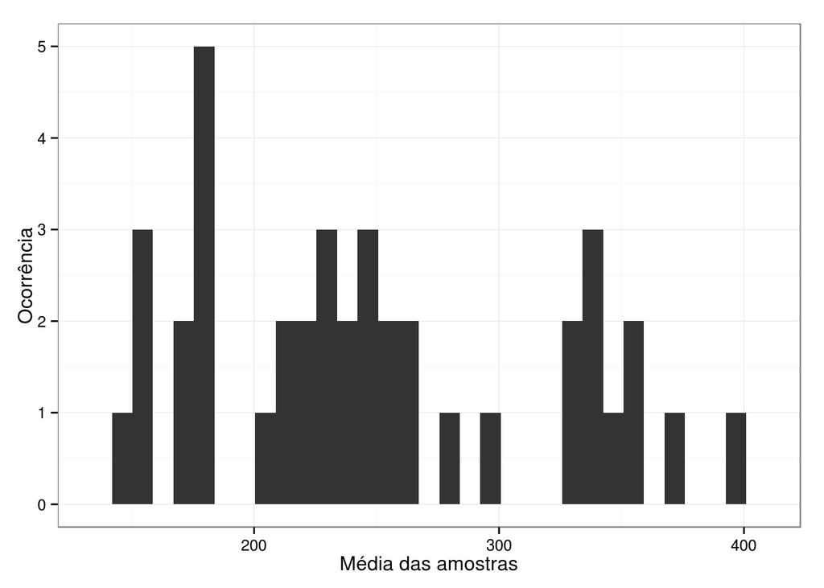

```r
# Média de 40 amostras com n = 100
samplesMeans <- mediaAmostra(vlrCombustiveis$vlrLiquido, 100, 40)
ggplot(data.frame(samplesMeans), aes(samplesMeans)) + geom_histogram() +  theme_bw() +
  labs(x='Média das amostras', y='Ocorrência')
```

Para a média de 80 amostras temos:

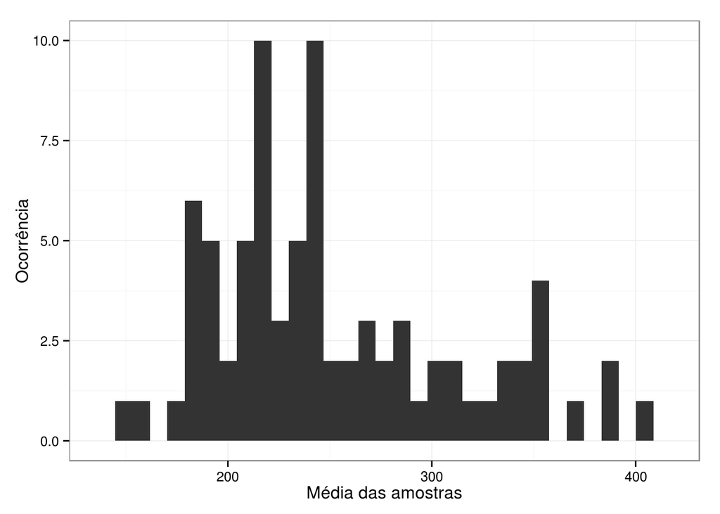

```r
# Média de 80 amostras com n = 100
samplesMeans <- mediaAmostra(vlrCombustiveis$vlrLiquido, 100, 80)
ggplot(data.frame(samplesMeans), aes(samplesMeans)) + geom_histogram() +  theme_bw() +
  labs(x='Média das amostras', y='Ocorrência')
```

Para a média de 160 amostras temos:

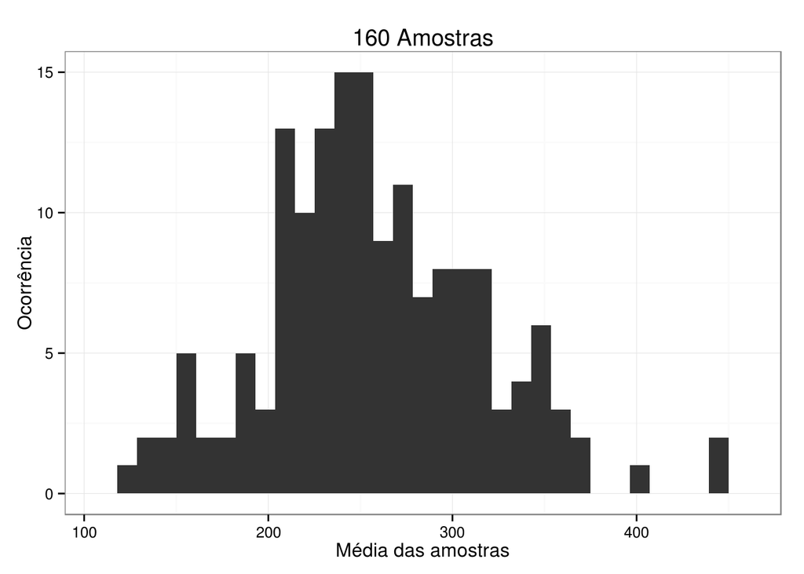

```r
# Média de 160 amostras com n = 100
samplesMeans <- mediaAmostra(vlrCombustiveis$vlrLiquido, 100, 160)
g2 <- ggplot(data.frame(samplesMeans), aes(samplesMeans)) + geom_histogram() +  theme_bw() +
  labs(x='Média das amostras', y='Ocorrência') + ggtitle("160 Amostras")
g2
```

Para a média de 320 amostras temos:

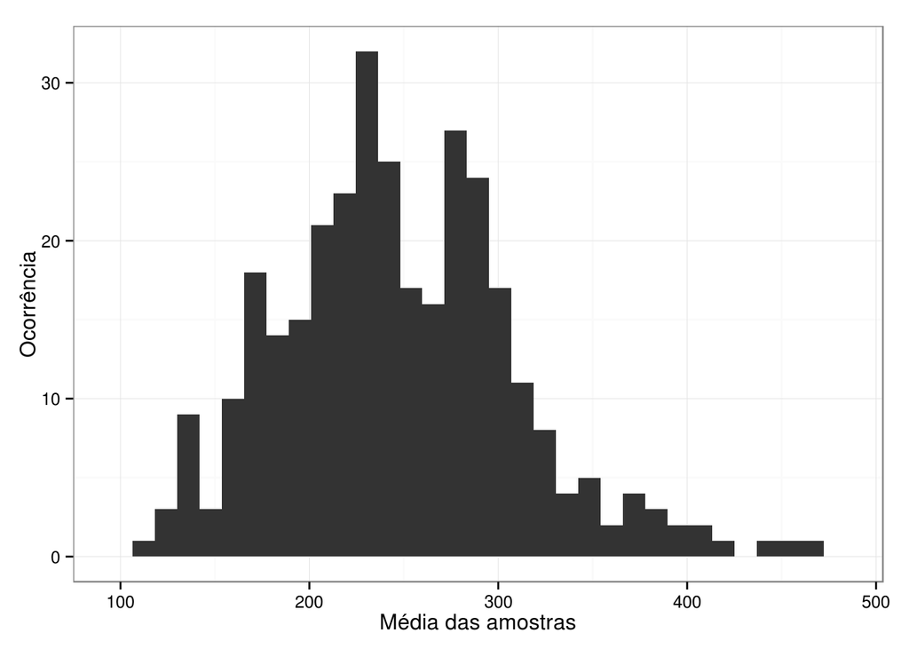

```r
# Média de 320 amostras com n = 100
samplesMeans <- mediaAmostra(vlrCombustiveis$vlrLiquido, 100, 320)
ggplot(data.frame(samplesMeans), aes(samplesMeans)) + geom_histogram() +  theme_bw() +
  labs(x='Média das amostras', y='Ocorrência')
```

Para a média de 640 amostras temos:

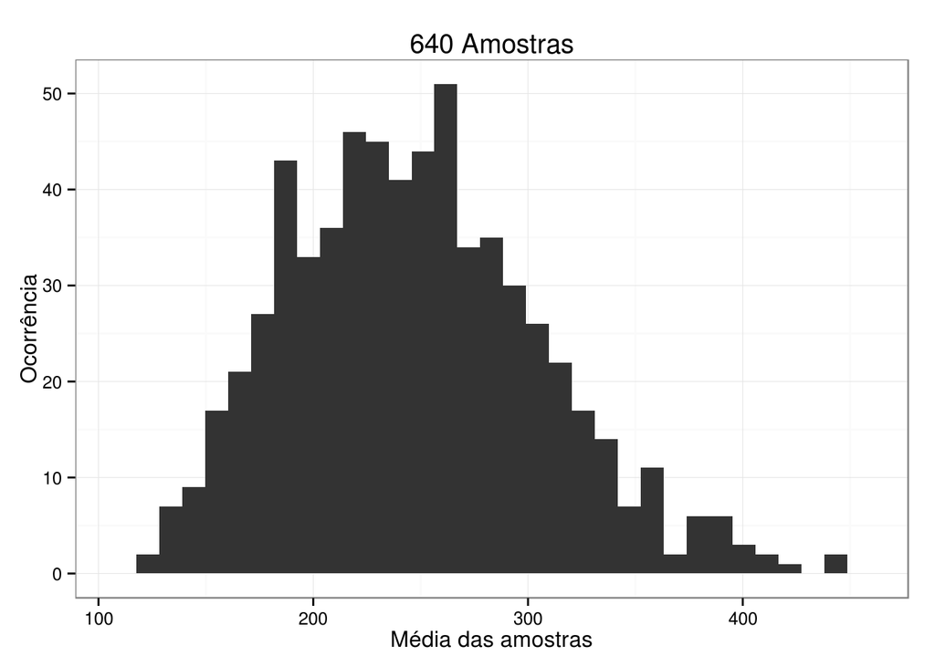

```r
# Média de 640 amostras com n = 100
samplesMeans <- mediaAmostra(vlrCombustiveis$vlrLiquido, 100, 640)
g3 <- ggplot(data.frame(samplesMeans), aes(samplesMeans)) + geom_histogram() +  theme_bw() +
  labs(x='Média das amostras', y='Ocorrência') + ggtitle("640 Amostras")
g3
```

É possível notar que quanto maior for o número das amostras mais próximo a distribuição se parece com a distribuição normal. Sendo o valor que mais aparece o valor bastante próximo do valor da média da população. Para uma melhor visualização da evolução observer os três gráficos abaixo.

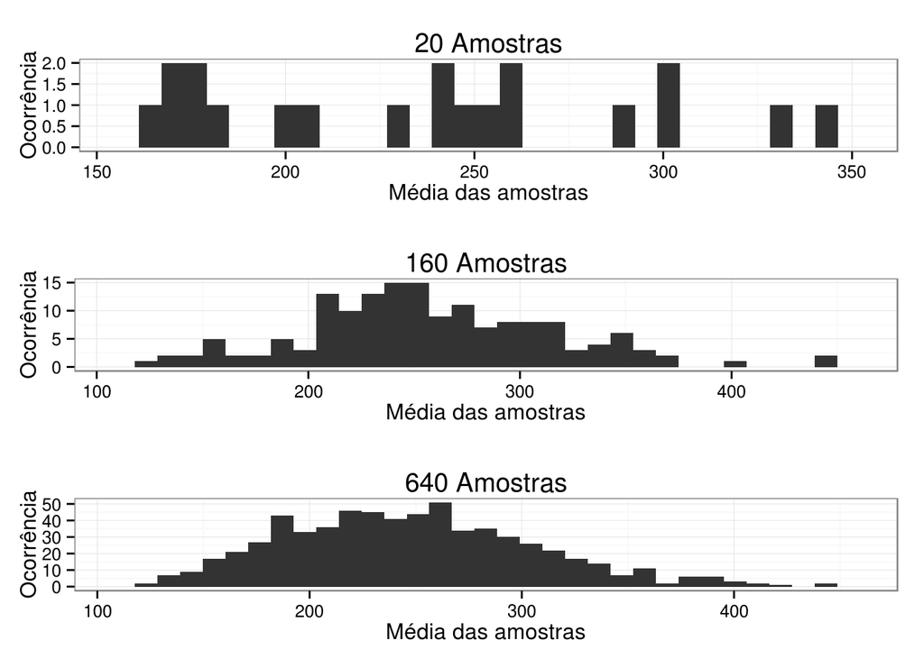

```r
multiplot <- function(..., plotlist=NULL, file, cols=1, layout=NULL) {
  require(grid)

  # Make a list from the ... arguments and plotlist
  plots <- c(list(...), plotlist)

  numPlots = length(plots)

  # If layout is NULL, then use 'cols' to determine layout
  if (is.null(layout)) {
    # Make the panel
    # ncol: Number of columns of plots
    # nrow: Number of rows needed, calculated from # of cols
    layout <- matrix(seq(1, cols * ceiling(numPlots/cols)),
                    ncol = cols, nrow = ceiling(numPlots/cols))
  }

 if (numPlots==1) {
    print(plots[[1]])

  } else {
    # Set up the page
    grid.newpage()
    pushViewport(viewport(layout = grid.layout(nrow(layout), ncol(layout))))

    # Make each plot, in the correct location
    for (i in 1:numPlots) {
      # Get the i,j matrix positions of the regions that contain this subplot
      matchidx <- as.data.frame(which(layout == i, arr.ind = TRUE))

      print(plots[[i]], vp = viewport(layout.pos.row = matchidx$row,
                                      layout.pos.col = matchidx$col))
    }
  }
}

multiplot(g1, g2, g3)
```